# Project_Final

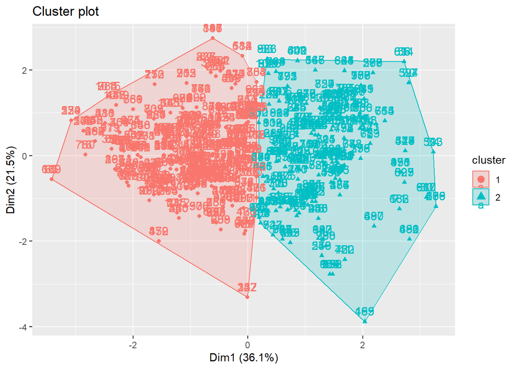

```r
fviz_cluster(k2, data = uns_df)
```

In the plot, there are two distinct clusters of data points, each highlighted with a different color and labeled as “1” and “2” in the legend under the label “cluster.” Cluster 1 is colored red and Cluster 2 is colored blue. These clusters are also enclosed within their respective convex hulls, which are the smallest convex polygons that can contain all the points of a cluster. This visual aid helps to emphasize the separation between the clusters.

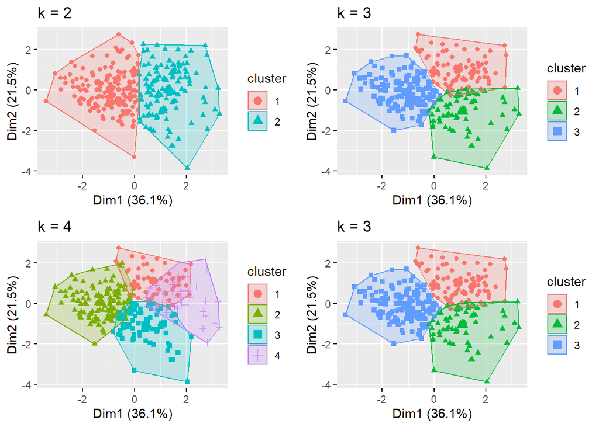

```r
k3 <- kmeans(uns_df, centers = 3, nstart = 25)
k4 <- kmeans(uns_df, centers = 4, nstart = 25)
k5 <- kmeans(uns_df, centers = 5, nstart = 25)

p1 <- fviz_cluster(k2, geom = "point", data = uns_df)+
  ggtitle("k = 2")
p2 <- fviz_cluster(k3, geom = "point", data = uns_df)+
  ggtitle("k = 3")
p3 <- fviz_cluster(k4, geom = "point", data = uns_df)+
  ggtitle("k = 4")
p4 <- fviz_cluster(k5, geom = "point", data = uns_df)+
  ggtitle("k = 5")

library(gridExtra)
grid.arrange(p1,p2,p3,p2, nrow = 2)
```

#Optimum cluster numbers

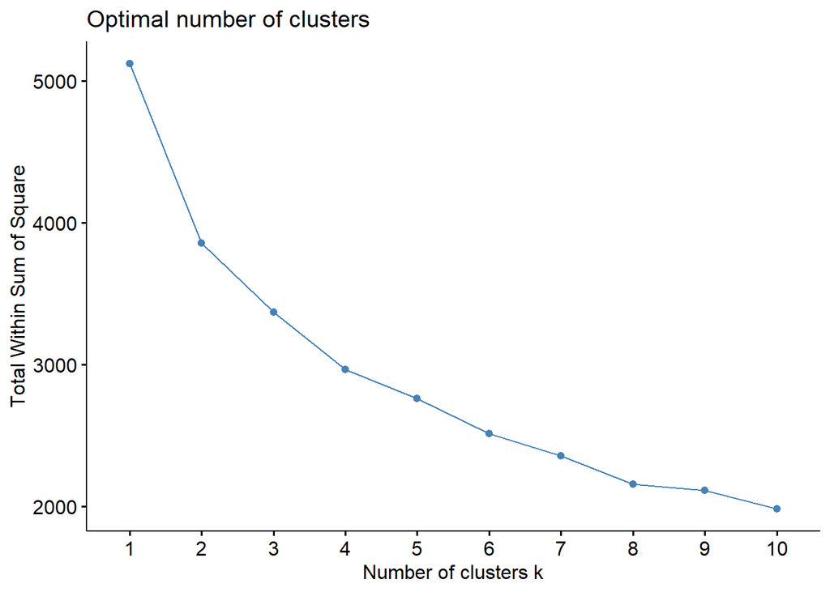

```r
# Elbow Method
set.seed(123)
fviz_nbclust(uns_df, kmeans, method = "wss")
```

In this plot, you can observe that as the number of clusters increases, the total WSS decreases. This is expected because when you increase the number of clusters, the clusters themselves become smaller and the points are closer to their respective centroids.

To find the optimal number of clusters, you look for the “elbow” point in the plot, which is the point after which the rate of decrease of WSS slows down significantly. This point represents a balance between minimizing the WSS and having a smaller number of clusters. In this plot, the elbow seems to appear around the 3 or 4 cluster mark, suggesting that 3 or 4 might be the optimal number of clusters for this particular dataset.

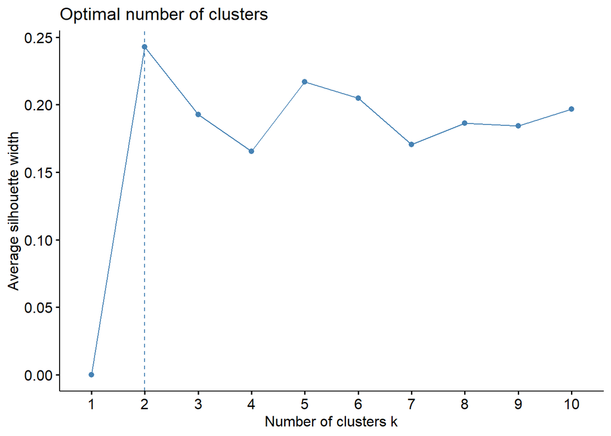

```r
# Average Silouette Method
fviz_nbclust(uns_df, kmeans, method = "silhouette")
```

#Gap_ Statistics

```r
library(cluster)
set.seed(123)

gap_stat <- clusGap(uns_df, FUN = kmeans, nstart = 25, K.max = 10, B = 50)
print(gap_stat, method = "firstmax")
```

```
## Clustering Gap statistic ["clusGap"] from call:
## clusGap(x = uns_df, FUNcluster = kmeans, K.max = 10, B = 50, nstart = 25)
## B=50 simulated reference sets, k = 1..10; spaceH0="scaledPCA"
##  --> Number of clusters (method 'firstmax'): 2
##           logW   E.logW       gap      SE.sim
##  [1,] 6.631293 7.189493 0.5581999 0.007180497
##  [2,] 6.484217 7.064241 0.5800238 0.006775992
##  [3,] 6.407674 6.978675 0.5710010 0.005937317
##  [4,] 6.353428 6.905347 0.5519184 0.006685759
##  [5,] 6.299485 6.849281 0.5497963 0.006182010
##  [6,] 6.253780 6.798893 0.5451135 0.006117756
##  [7,] 6.211680 6.761185 0.5495051 0.005998341
##  [8,] 6.184648 6.728249 0.5436015 0.006480379
##  [9,] 6.156408 6.702161 0.5457528 0.006160733
## [10,] 6.126893 6.678288 0.5513945 0.006073452
```

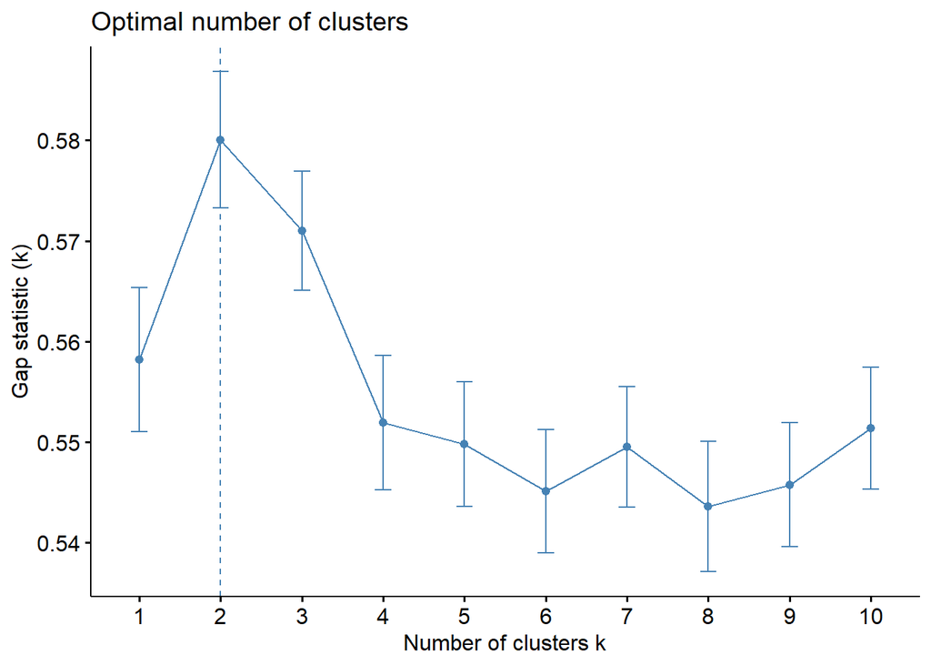

```r
fviz_gap_stat(gap_stat)
```

```r
set.seed(123)

final <- kmeans(uns_df, 2, nstart = 25)
final
```

```
## K-means clustering with 2 clusters of sizes 430, 595
##
## Cluster means:
##          age   trestbps       chol    thalach    oldpeak
## 1  0.7165487  0.4880342  0.3754376 -0.6496950  0.6284718
## 2 -0.5178419 -0.3526970 -0.2713246  0.4695275 -0.4541897
##
## Clustering vector:
##    [1] 2 1 1 2 1 2 1 1 2 1 1 1 2 1 2 2 1 1 2 2 1 2 2 2 2 1 2 1 2 1 2 2 1 1 2 1 2
##   [38] 2 1 2 1 2 2 2 1 2 2 1 1 2 1 1 2 2 1 1 2 2 1 2 2 1 1 1 2 1 2 1 2 1 1 1 2 2
##   [75] 2 2 2 1 2 2 2 2 1 2 2 2 2 1 1 1 2 2 1 2 2 2 2 1 2 1 2 2 2 2 2 2 2 1 2 2 2
##  [112] 1 2 1 1 1 1 2 2 2 2 2 1 1 1 2 1 2 2 2 2 2 2 2 2 1 1 1 2 2 1 2 1 2 2 2 2 2
##  [149] 2 2 1 2 2 2 1 2 2 2 1 2 1 2 1 2 2 1 1 2 2 2 2 1 2 2 1 1 1 1 2 1 1 1 1 2 2
##  [186] 1 2 2 1 1 2 2 1 1 1 1 2 2 2 2 2 2 2 1 1 2 1 2 2 1 2 1 1 2 2 2 1 2 1 1 2 1
##  [223] 1 2 2 2 2 2 2 1 2 2 1 2 2 1 2 2 2 1 2 1 2 1 2 2 2 1 2 2 2 2 1 1 2 1 2 1 2
```

[output cut: 30 more lines]

# Descriptive Statistics for Clusters

```r
data2[,10:14] %>%
  mutate(Cluster = final$cluster) %>%
  group_by(Cluster) %>%
  summarise_all("mean")
```

```
## # A tibble: 2 × 6
##   Cluster   age trestbps  chol thalach oldpeak
##     <int> <dbl>    <dbl> <dbl>   <dbl>   <dbl>
## 1       1  60.9     140.  265.    134.   1.81
## 2       2  49.7     125.  232.    160.   0.538
```

# HIERARCHICAL CLUSTERING

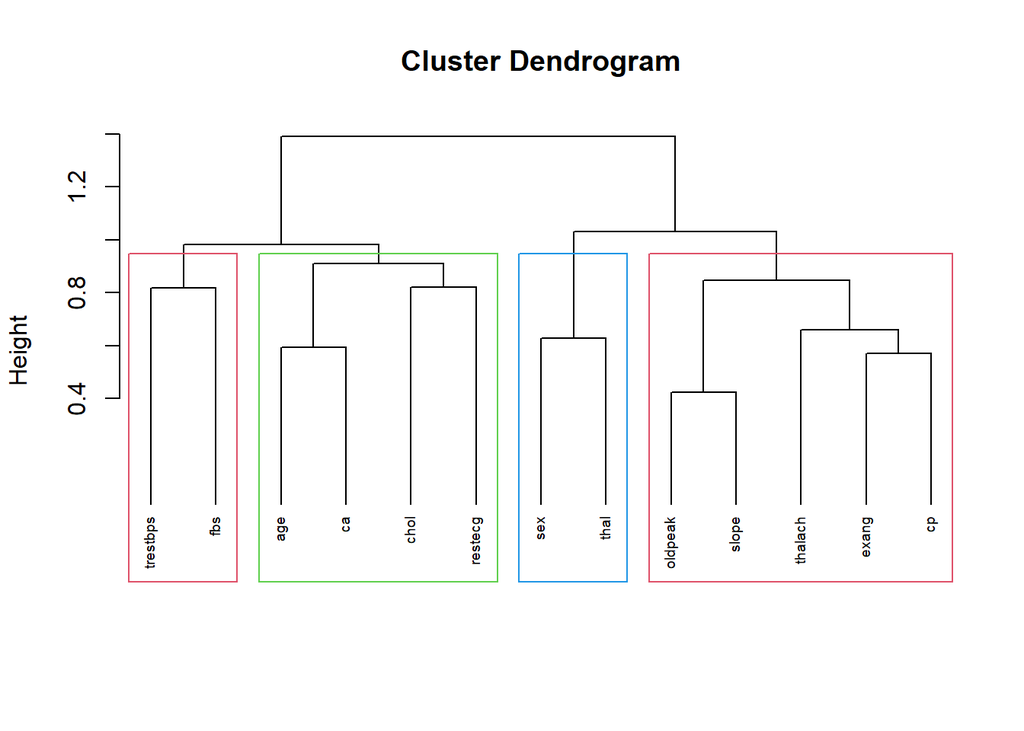

```r
xquant <- data2[10:14] # Numeric variables
xqual <- data2[2:9]    # Categorical variables
tree <- hclustvar(xquant, xqual)
plot(tree, cex = 0.6)
rect.hclust(tree, k = 4, border = 2:4)
```

In the dendrogram shown, you can see several clusters being merged at different heights. The decision on the number of clusters can be made by cutting the dendrogram at a certain height, which will define clusters as the number of vertical lines that are intersected by the horizontal line.

```r
stab <- stability(tree, B=50) # "B=50" refers to the number of bootstrap samples to use in the estimation.
```

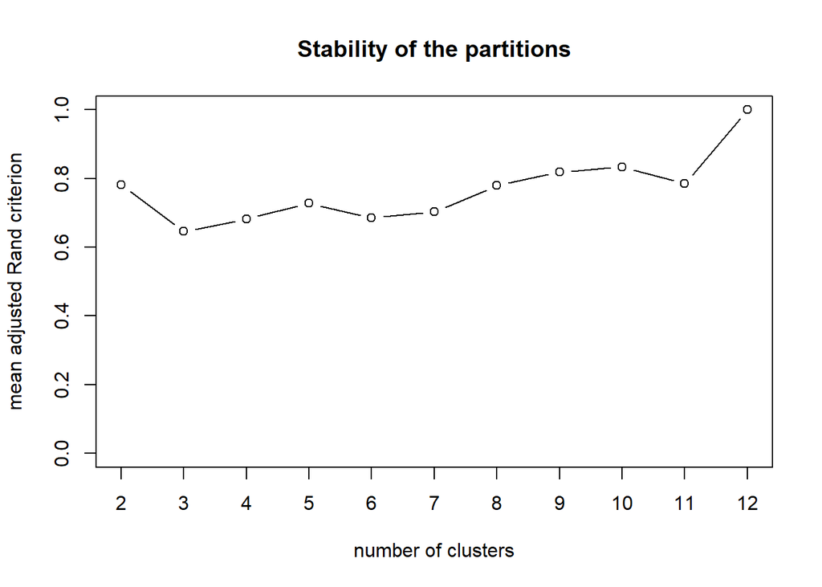

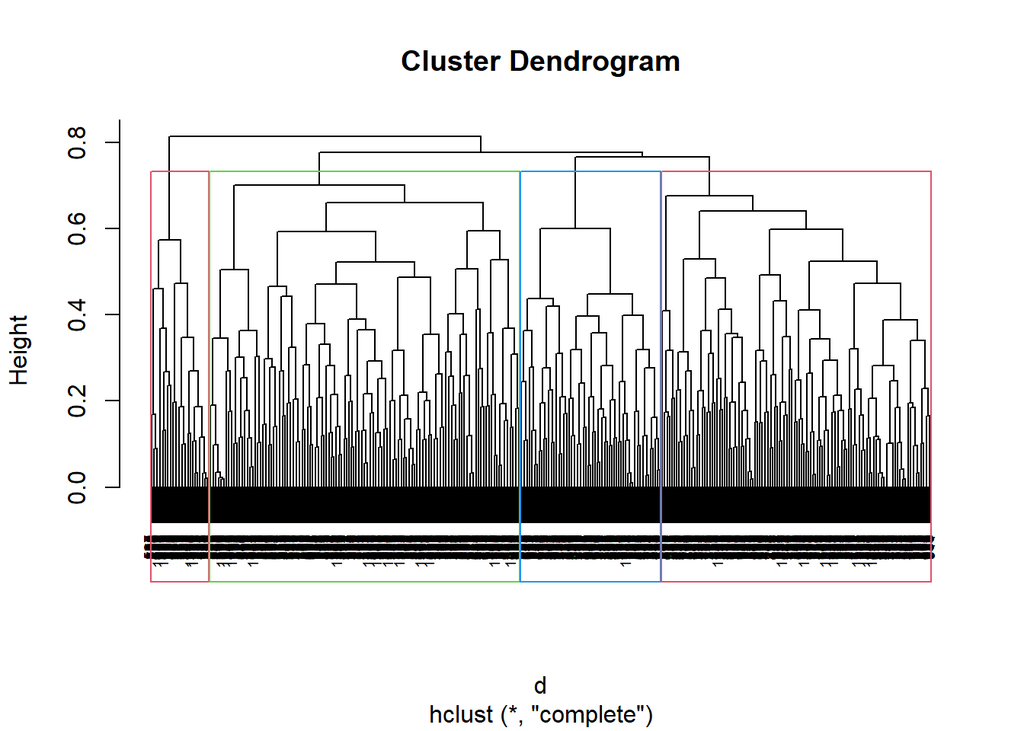

```r
d <- daisy(data2[-1], metric="gower")

fit <- hclust(d=d, method="complete")    # Also try: method="ward.D"

plot(fit, cex = 0.6)
rect.hclust(fit, k = 4, border = 2:4)
```

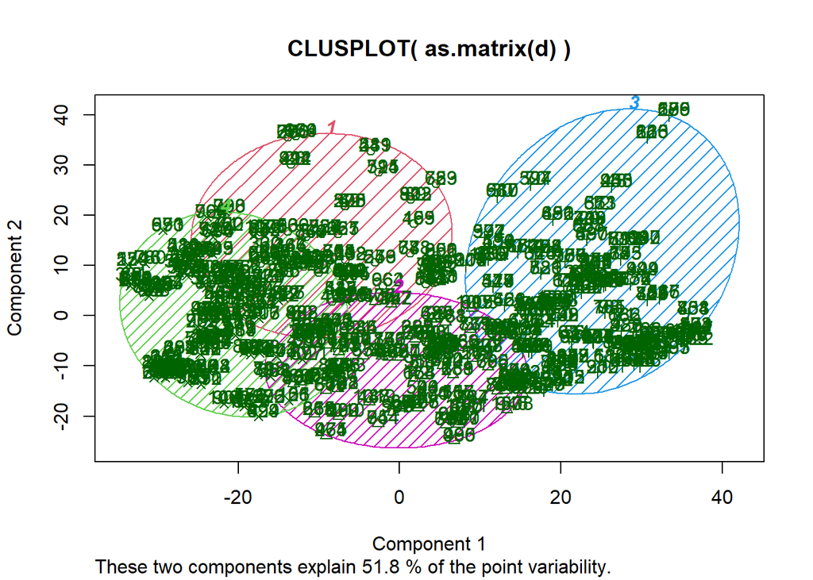

```r
kfit <- kmeans(d, 4)
clusplot(as.matrix(d), kfit$cluster, color=T, shade=T, labels=2, lines=0)
```

# Plot the first two principal components with cluster assignments

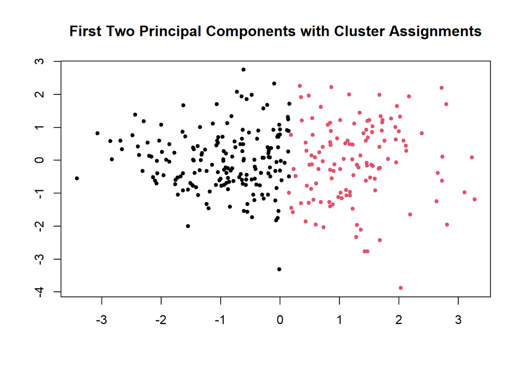

```r
# Perform PCA
pc <- prcomp(uns_df)

# Extract the first two principal components
pc_first_two <- pc$x[, 1:2]

# Perform K-means clustering on the first two principal components
set.seed(12)  # For reproducibility
k <- 2  # Number of clusters
km_clusters <- kmeans(pc_first_two, centers = k)

# Plot the first two principal components with cluster assignments
plot(pc_first_two, col = km_clusters$cluster,
     main = "First Two Principal Components with Cluster Assignments",
     xlab = "", ylab = "", pch = 20)
```

The plot displays a scatterplot of data points reduced to two dimensions using Principal Component Analysis (PCA), where the first two principal components are plotted along the x and y axes, respectively. The data points are colored to represent two distinct clusters, as identified by a clustering algorithm, with black and red dots indicating the separate groupings. The plot’s purpose is to illustrate the variance captured by PCA and the natural groupings within the data as determined by the clustering, enabling visualization and analysis of patterns within a high-dimensional dataset in a simplified two-dimensional space.

```r
library(NbClust)
res.nbclust <- data %>% scale() %>% NbClust(distance = "euclidean", min.nc = 2, max.nc = 10, method = "complete", index ="all")
```

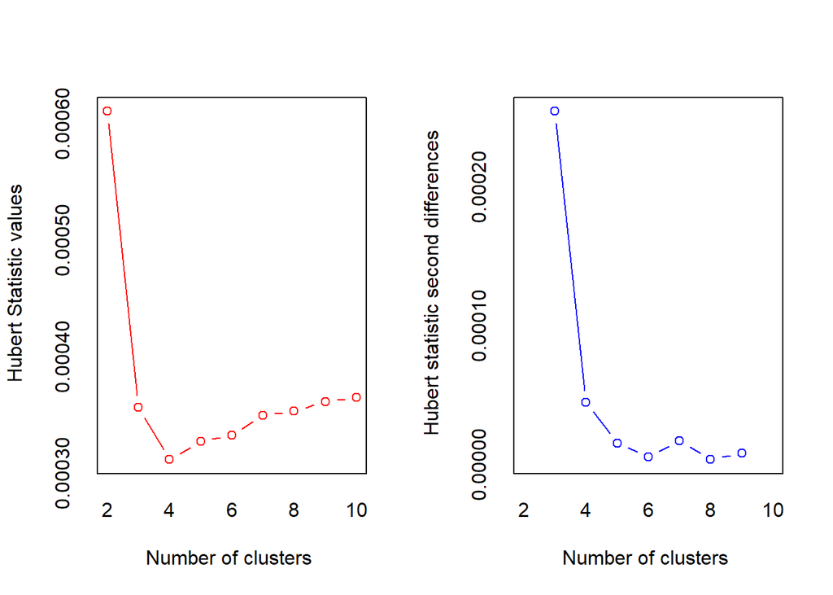

```
## *** : The Hubert index is a graphical method of determining the number of clusters.
##                 In the plot of Hubert index, we seek a significant knee that corresponds to a
##                 significant increase of the value of the measure i.e the significant peak in Hubert
##                 index second differences plot.
##
```

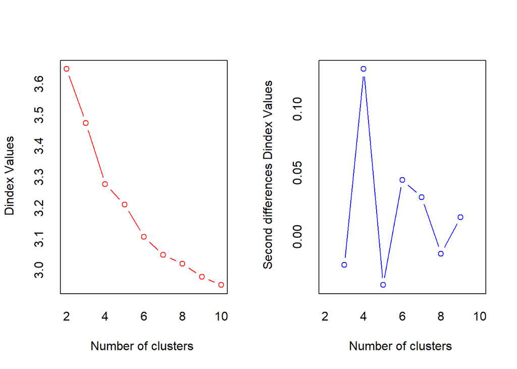

```
## *** : The D index is a graphical method of determining the number of clusters.
##                 In the plot of D index, we seek a significant knee (the significant peak in Dindex
##                 second differences plot) that corresponds to a significant increase of the value of
##                 the measure.
##
## * Among all indices:
## * 9 proposed 2 as the best number of clusters
## * 2 proposed 3 as the best number of clusters
## * 7 proposed 4 as the best number of clusters
## * 1 proposed 5 as the best number of clusters
## * 1 proposed 6 as the best number of clusters
## * 4 proposed 7 as the best number of clusters
##
##                    ***** Conclusion *****
##
## * According to the majority rule, the best number of clusters is  2
##
##
```

#Factor_Analysis

```r
# Load necessary library
library(psych)
# Subset the dataset to include only columns 10 to 14
subset_data <- data2[, 10:14]

# Perform Factor Analysis
fit.pc <- principal(subset_data, nfactors = 3, rotate = "varimax")

# View factor analysis results
fit.pc
```

```
## Principal Components Analysis
## Call: principal(r = subset_data, nfactors = 3, rotate = "varimax")
## Standardized loadings (pattern matrix) based upon correlation matrix
##            RC1   RC2  RC3   h2    u2 com
## age       0.58  0.47 0.24 0.61 0.390 2.3
## trestbps  0.08  0.10 0.96 0.94 0.064 1.0
## chol     -0.03  0.93 0.05 0.87 0.126 1.0
## thalach  -0.87 -0.06 0.16 0.79 0.214 1.1
## oldpeak   0.68 -0.11 0.28 0.56 0.442 1.4
##
##                        RC1  RC2  RC3
## SS loadings           1.57 1.11 1.08
## Proportion Var        0.31 0.22 0.22
## Cumulative Var        0.31 0.54 0.75
## Proportion Explained  0.42 0.30 0.29
## Cumulative Proportion 0.42 0.71 1.00
##
## Mean item complexity =  1.4
## Test of the hypothesis that 3 components are sufficient.
##
## The root mean square of the residuals (RMSR) is  0.14
##  with the empirical chi square  400.78  with prob <  NA
##
## Fit based upon off diagonal values = 0.61
```

Variables (Rows): The rows represent different variables included in the factor analysis. These are ‘age’, ‘trestbps’ (resting blood pressure), ‘chol’ (cholesterol), ‘thalach’ (maximum heart rate achieved), and ‘oldpeak’ (ST depression induced by exercise relative to rest).

Factors (RC1, RC2, RC3): The columns labeled RC1, RC2, and RC3 represent the factor loadings on three extracted factors. Factor loadings can be interpreted similarly to correlation coefficients between the observed variables and the latent factors. For example, ‘age’ has a loading of 0.58 on RC1, indicating a moderate positive association with the first factor.

Communalities (h2): This column represents the communalities (h2), which are estimates of the proportion of each variable’s variance that is accounted for by the common factors. For instance, the communality for ‘age’ is 0.6101805, suggesting that approximately 61% of the variance in age can be explained by the three factors together.

Complexity (com): The last column represents the complexity (com) of the variables. Complexity indicates how many factors significantly load on a variable. A complexity value close to 1 suggests that the variable is primarily associated with one factor, while a higher value indicates that the variable is complexly determined by multiple factors. For example, ‘age’ has a complexity of 2.267834, indicating that it’s influenced by more than one factor.

#Factor Loadings

```r
round(fit.pc$values, 3)
```

```
## [1] 1.804 1.076 0.883 0.759 0.479
```

```r
fit.pc$loadings
```

```
##
## Loadings:
##          RC1    RC2    RC3
## age       0.581  0.466  0.235
## trestbps                0.959
## chol             0.933
## thalach  -0.871         0.156
## oldpeak   0.684 -0.113  0.277
##
##                  RC1   RC2   RC3
## SS loadings    1.570 1.113 1.079
## Proportion Var 0.314 0.223 0.216
## Cumulative Var 0.314 0.537 0.753
```

# Communalities

```r
fit.pc$communality
```

```
##       age  trestbps      chol   thalach   oldpeak
## 0.6101805 0.9355137 0.8737971 0.7855377 0.5575853
```

```r
# Rotated factor scores, Notice the columns ordering: RC1, RC3, RC2 and RC4
fit.pc$scores
```

```
##                 RC1          RC2          RC3
##    [1,] -0.48496963 -0.621396151 -0.083036723
##    [2,]  0.60745480 -1.203041549  0.918186630
##    [3,]  1.83373196 -0.999177042  0.922091583
##    [4,] -0.46937513 -0.334755852  0.972438909
##    [5,]  1.54310620  0.894367840 -0.089135614
##    [6,]  0.97698050  0.282485542 -1.994612785
##    [7,]  1.51161155  0.788561508 -0.596296505
##    [8,] -0.23624868  0.698468187  1.329404050
##    [9,] -0.19651722 -0.175795538 -0.799769779
##   [10,]  1.59721663  0.273832375 -0.648080374
##   [11,]  1.74168413 -1.073925394 -0.931962326
##   [12,]  0.43174536  0.811464252 -0.096812658
##   [13,] -1.79585392 -1.236266649 -0.351655312
##   [14,]  1.57846773  0.111176073  0.495477322
```

[output cut: 1011 more lines]

# Play with FA utilities

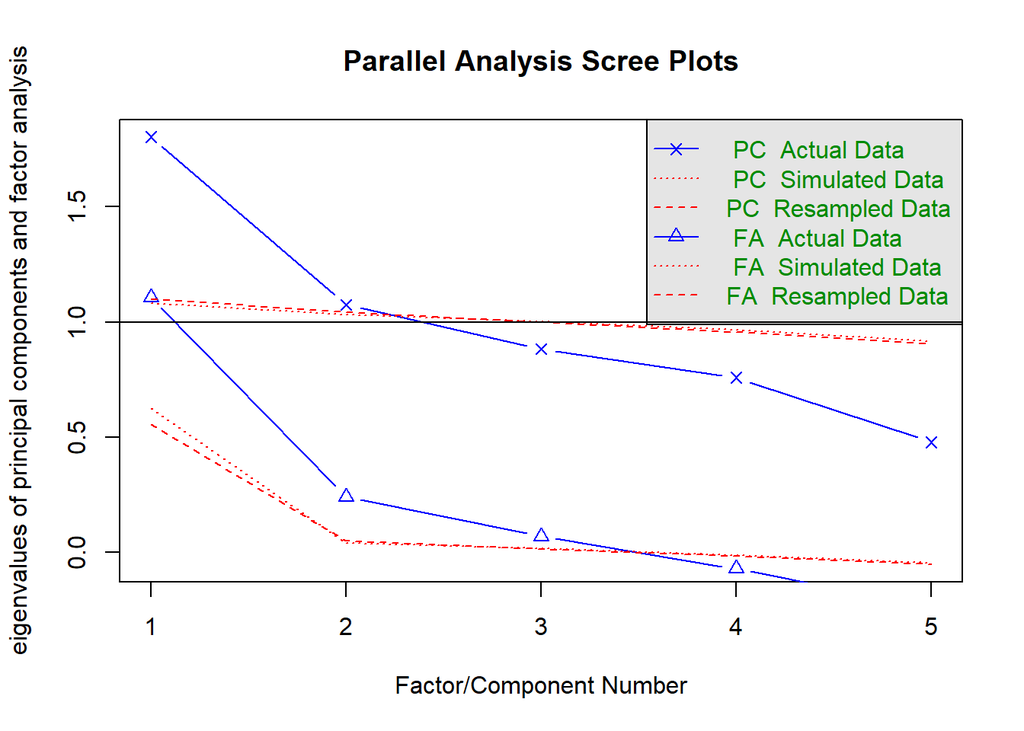

```
## Parallel analysis suggests that the number of factors =  3  and the number of components =  2
```

```r
fa.parallel(data2[, 10:14]) # See factor recommendation
```

In the plot, there are six lines representing different data:

“PC Actual Data” (marked with ‘X’) shows the eigenvalues for each principal component from the actual dataset.

“PC Simulated Data” (dotted line) represents the average eigenvalues for each component from the simulated datasets.

“PC Resampled Data” (dashed line) represents the eigenvalues from a resampling of the actual data (e.g., bootstrapping).

“FA Actual Data” (marked with ‘Δ’) shows the eigenvalues for each factor from the actual dataset using factor analysis.

“FA Simulated Data” (dotted line) represents the average eigenvalues for each factor from the simulated datasets using factor analysis.

“FA Resampled Data” (dashed line) represents the eigenvalues from a resampling of the actual data using factor analysis.

# See Correlations within Factors

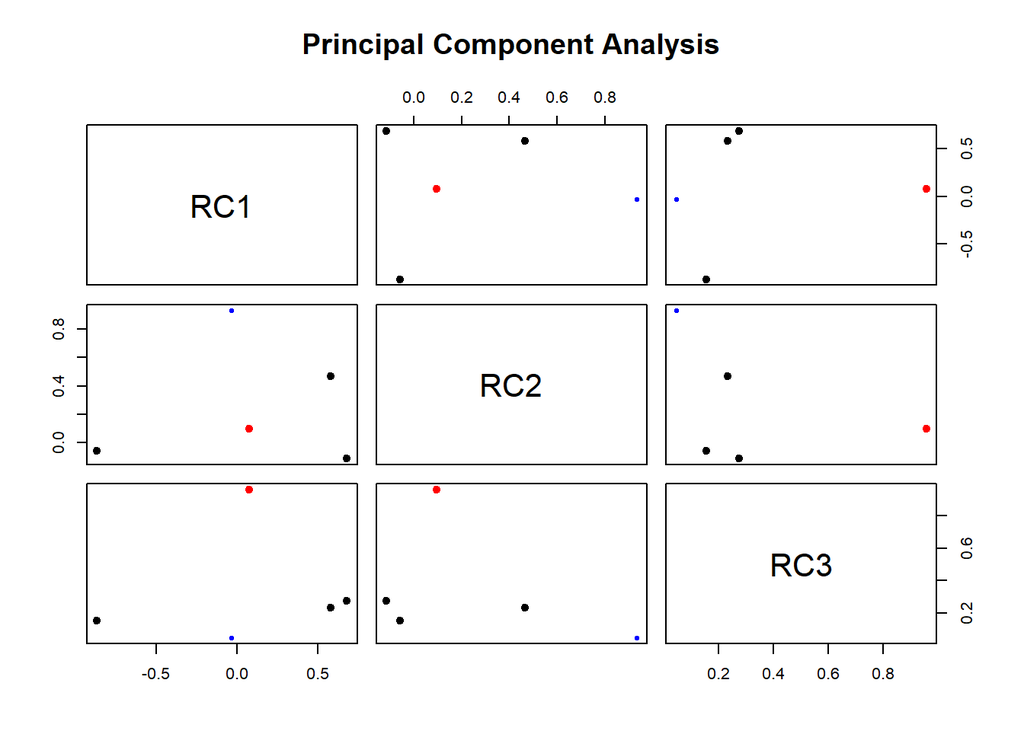

```r
fa.plot(fit.pc)
```

# Visualize the relationship

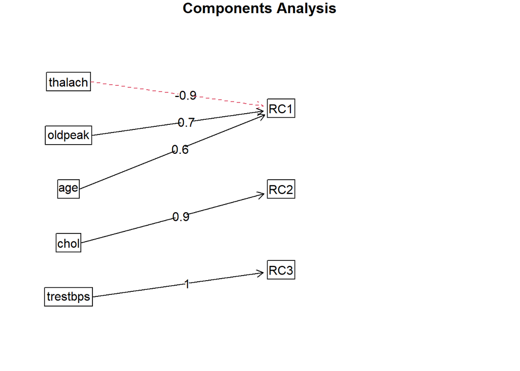

```r
fa.diagram(fit.pc)
```

Interpreting the plot:

‘thalach’ has a strong negative correlation with RC1, as indicated by the loading score of -0.9 and the dashed line.

‘oldpeak’ has a somewhat strong positive correlation with RC1, with a loading score of 0.7.

‘age’ has a moderate positive correlation with RC1, indicated by the loading score of 0.6.

‘chol’ has a strong positive correlation with RC2, with a loading score of 0.9.

RC1 might represent some form of heart health factor, given that ‘thalach’ (maximum heart rate achieved) is negatively correlated (as heart rate might decrease with certain heart conditions) and ‘oldpeak’ (ST depression induced by exercise relative to rest) is positively correlated with it, as higher values of ST depression can be associated with heart issues. RC2 and RC3 could represent other underlying factors or components that describe different dimensions of variation in the data.

# See Factor recommendations for a simple structure

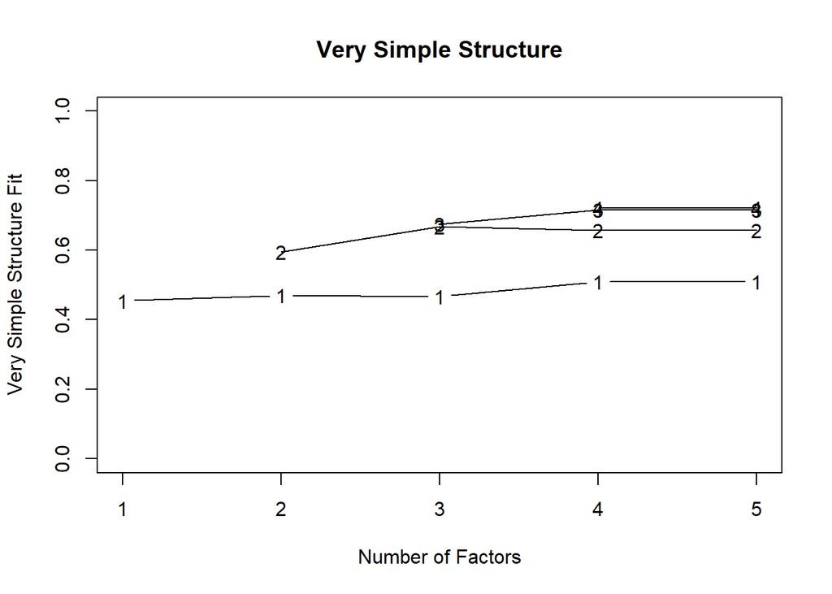

```
##
## Very Simple Structure
## Call: vss(x = data2[, 10:14])
## Although the VSS complexity 1 shows  4  factors, it is probably more reasonable to think about  2  factors
## VSS complexity 2 achieves a maximimum of 0.67  with  3  factors
##
## The Velicer MAP achieves a minimum of 0.08  with  1  factors
## BIC achieves a minimum of  10.21  with  2  factors
## Sample Size adjusted BIC achieves a minimum of  13.39  with  2  factors
##
## Statistics by number of factors
##   vss1 vss2   map dof   chisq    prob sqresid  fit RMSEA BIC SABIC complex
## 1 0.45 0.00 0.081   5 1.2e+02 8.5e-24     3.3 0.45  0.15  83    99     1.0
## 2 0.47 0.60 0.180   1 1.7e+01 3.5e-05     2.4 0.60  0.13  10    13     1.3
## 3 0.47 0.67 0.380  -2 9.6e-11      NA     1.9 0.67    NA  NA    NA     1.5
## 4 0.51 0.66 1.000  -4 0.0e+00      NA     1.7 0.72    NA  NA    NA     1.6
## 5 0.51 0.66    NA  -5 0.0e+00      NA     1.7 0.72    NA  NA    NA     1.6
##    eChisq    SRMR eCRMS eBIC
## 1 1.3e+02 7.9e-02 0.112   94
## 2 1.7e+01 2.9e-02 0.091   10
## 3 9.9e-11 6.9e-08    NA   NA
## 4 2.6e-14 1.1e-09    NA   NA
## 5 2.6e-14 1.1e-09    NA   NA
```

```r
vss(data2[, 10:14])
```

# Computing Correlation Matrix

```r
corrm.data <- cor(data2[, 10:14])
corrm.data
```

```
##                 age    trestbps        chol     thalach     oldpeak
## age       1.0000000  0.27112141  0.21982253 -0.39022708  0.20813668
## trestbps  0.2711214  1.00000000  0.12797743 -0.03926407  0.18743411
## chol      0.2198225  0.12797743  1.00000000 -0.02177209  0.06488031
## thalach  -0.3902271 -0.03926407 -0.02177209  1.00000000 -0.34979616
## oldpeak   0.2081367  0.18743411  0.06488031 -0.34979616  1.00000000
```

This is a correlation matrix showing the pairwise correlations between the variables: age, trestbps (resting blood pressure), chol (serum cholesterol), thalach (maximum heart rate achieved), and oldpeak (ST depression induced by exercise relative to rest). Each cell in the matrix represents the correlation coefficient between two variables. For example, the correlation between age and trestbps is 0.271, indicating a weak positive correlation, while the correlation between thalach and oldpeak is -0.350, indicating a moderate negative correlation. This matrix helps understand how each variable is related to the others in the dataset, providing insights into potential relationships and dependencies between variables.

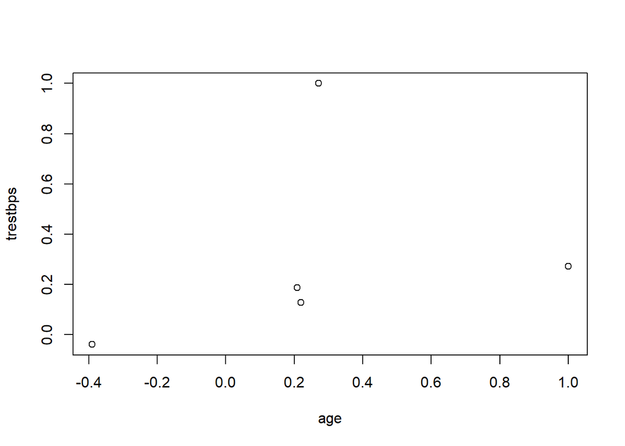

```r
plot(corrm.data)
```

#importance of each principal component

```r
data2_pca <- prcomp(data2[, 10:14], scale = TRUE)
summary(data2_pca)
```

```
## Importance of components:
##                           PC1    PC2    PC3    PC4     PC5
## Standard deviation     1.3430 1.0371 0.9399 0.8710 0.69186
## Proportion of Variance 0.3607 0.2151 0.1767 0.1517 0.09573
## Cumulative Proportion  0.3607 0.5758 0.7525 0.9043 1.00000
```

This result summarizes the importance of each principal component (PC) extracted from a dimensionality reduction technique like Principal Component Analysis (PCA).

Standard Deviation: It represents the variability of the data captured by each principal component. Larger standard deviations indicate that the corresponding PCs explain more variance in the original data. Proportion of Variance: It shows the proportion of the total variance in the data explained by each principal component. For example, PC1 explains 36.07% of the total variance, PC2 explains 21.51%, and so on. Cumulative Proportion: It represents the cumulative proportion of variance explained by the principal components. In this case, the first PC alone explains 36.07% of the variance, while the first two PCs combined explain 57.58%, and so on. These values help in understanding the relative importance of each principal component in capturing the variability of the original dataset.

#Plotting Variances of PCs

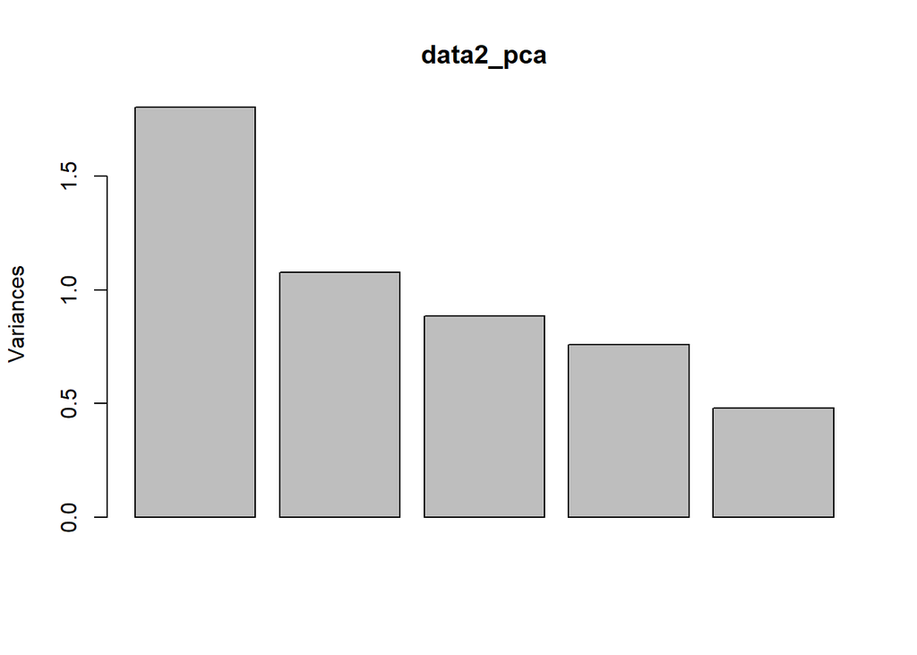

```r
plot(data2_pca)
```

```r
# A table containing eigenvalues and %'s accounted, follows. Eigenvalues are the sdev^2
(eigen_data2 <- round(data2_pca$sdev^2,3))
```

```
## [1] 1.804 1.076 0.883 0.759 0.479
```

```r
round(fit.pc$values, 3)
```

```
## [1] 1.804 1.076 0.883 0.759 0.479
```

#Eigen values

```r
eigen_data2 <- data2_pca$sdev^2
names(eigen_data2) <- paste("PC", 1:5, sep = "")
eigen_data2
```

```
##       PC1       PC2       PC3       PC4       PC5
## 1.8035898 1.0755283 0.8834962 0.7587172 0.4786685
```

#Sum of eigen values

```r
sumlambdas <- sum(eigen_data2)
sumlambdas
```

```
## [1] 5
```

#calculates the proportion of variance

```r
propvar <- round(eigen_data2/sumlambdas,2)
propvar
```

```
##  PC1  PC2  PC3  PC4  PC5
## 0.36 0.22 0.18 0.15 0.10
```

```r
cumvar_data2 <- cumsum(propvar)
cumvar_data2
```

```
##  PC1  PC2  PC3  PC4  PC5
## 0.36 0.58 0.76 0.91 1.01
```

```r
matlambdas <- rbind(eigen_data2,propvar,cumvar_data2)
matlambdas
```

```
##                  PC1      PC2       PC3       PC4       PC5
## eigen_data2  1.80359 1.075528 0.8834962 0.7587172 0.4786685
## propvar      0.36000 0.220000 0.1800000 0.1500000 0.1000000
## cumvar_data2 0.36000 0.580000 0.7600000 0.9100000 1.0100000
```

```r
rownames(matlambdas) <- c("Eigenvalues","Prop. variance","Cum. prop. variance")
rownames(matlambdas)
```

```
## [1] "Eigenvalues"         "Prop. variance"      "Cum. prop. variance"
```

```r
eigvec.data2 <- data2_pca$rotation
print(data2_pca)
```

```
## Standard deviations (1, .., p=5):
## [1] 1.3429780 1.0370768 0.9399448 0.8710437 0.6918587
##
## Rotation (n x k) = (5 x 5):
##                 PC1        PC2        PC3        PC4        PC5
## age       0.5635382 -0.1059946 -0.1692945 -0.5419762  0.5905854
## trestbps  0.3671043 -0.4530454  0.7306853 -0.1215011 -0.3336476
## chol      0.2644374 -0.6602155 -0.5618229  0.3814106 -0.1818500
## thalach  -0.5044408 -0.4968335  0.2629944  0.1778681  0.6307874
## oldpeak   0.4725161  0.3174696  0.2294065  0.7172086  0.3300395
```

# Taking the first four PCs to generate linear combinations for all the variables with four factors

```r
pcafactors.data2 <- eigvec.data2[,1:4]
pcafactors.data2
```

```
##                 PC1        PC2        PC3        PC4
## age       0.5635382 -0.1059946 -0.1692945 -0.5419762
## trestbps  0.3671043 -0.4530454  0.7306853 -0.1215011
## chol      0.2644374 -0.6602155 -0.5618229  0.3814106
## thalach  -0.5044408 -0.4968335  0.2629944  0.1778681
## oldpeak   0.4725161  0.3174696  0.2294065  0.7172086
```

# Multiplying each column of the eigenvector’s matrix by the square-root of the corresponding eigenvalue in order to get the factor loadings

```r
unrot.fact.data2 <- sweep(pcafactors.data2,MARGIN=2,data2_pca$sdev[1:4],`*`)
unrot.fact.data2
```

```
##                 PC1        PC2        PC3        PC4
## age       0.7568194 -0.1099246 -0.1591275 -0.4720850
## trestbps  0.4930130 -0.4698429  0.6868038 -0.1058328
## chol      0.3551336 -0.6846942 -0.5280825  0.3322253
## thalach  -0.6774529 -0.5152545  0.2472003  0.1549309
## oldpeak   0.6345787  0.3292403  0.2156295  0.6247201
```

# Computing communalities

```r
communalities.data2 <- rowSums(unrot.fact.data2^2)
communalities.data2
```

```
##       age  trestbps      chol   thalach   oldpeak
## 0.8330447 0.9467143 0.9841707 0.8095413 0.9478605
```

# Performing the varimax rotation. The default in the varimax function is norm=TRUE thus, Kaiser normalization is carried out

```r
rot.fact.data2 <- varimax(unrot.fact.data2)
rot.fact.data2
```

```
## $loadings
##
## Loadings:
##          PC1    PC2    PC3    PC4
## age       0.832 -0.205  0.310
## trestbps                0.962  0.112
## chol            -0.988
## thalach  -0.793         0.167 -0.380
## oldpeak   0.141         0.125  0.954
##
##                  PC1   PC2   PC3   PC4
## SS loadings    1.351 1.031 1.068 1.072
## Proportion Var 0.270 0.206 0.214 0.214
## Cumulative Var 0.270 0.476 0.690 0.904
##
## $rotmat
##            [,1]       [,2]       [,3]      [,4]
## [1,]  0.7308539 -0.2732704  0.3836183 0.4939766
## [2,]  0.2609835  0.7008221 -0.5235769 0.4081707
## [3,] -0.3179240  0.5551585  0.7417030 0.2014945
## [4,] -0.5446692 -0.3549236 -0.1690590 0.7407994
```

# The print method of varimax omits loadings less than abs(0.1). In order to display all the loadings, it is necessary to ask explicitly the contents of the object $loadings

```r
fact.load.data2 <- rot.fact.data2$loadings
fact.load.data2
```

```
##
## Loadings:
##          PC1    PC2    PC3    PC4
## age       0.832 -0.205  0.310
## trestbps                0.962  0.112
## chol            -0.988
## thalach  -0.793         0.167 -0.380
## oldpeak   0.141         0.125  0.954
##
##                  PC1   PC2   PC3   PC4
## SS loadings    1.351 1.031 1.068 1.072
## Proportion Var 0.270 0.206 0.214 0.214
## Cumulative Var 0.270 0.476 0.690 0.904
```

```r
# Computing the rotated factor scores for the data. Notice that signs are reversed for factors F2, F3, and F4
scale.emp <- scale(data2[, 10:14])
factor_scores <- as.matrix(scale.emp) %*% fact.load.data2 %*% solve(t(fact.load.data2) %*% fact.load.data2)
factor_scores
```

```
##                  PC1          PC2          PC3          PC4
##    [1,] -0.583410927  0.509304952 -0.102224021 -0.142728313
##    [2,] -0.568613357  0.776468666  0.608248296  1.631991709
##    [3,]  1.576274729  1.449581871  0.912647290  0.808690135
##    [4,]  0.330921550  0.826540668  1.228172201 -1.228224704
##    [5,]  1.457605903 -0.681971775 -0.117838092  0.765955603
##    [6,]  1.135473711 -0.065448151 -1.946863759 -0.000729923
##    [7,] -0.044908176 -1.553313522 -1.081131817  2.699355953
##    [8,] -0.004231532 -0.628717353  1.380594592 -0.160288722
##    [9,] -0.399110908 -0.020731857 -0.864284319  0.121315256
##   [10,]  0.480508696 -0.670469191 -0.978131312  2.027211683
##   [11,]  2.006824867  1.764570990 -0.787417120 -0.081985052
##   [12,] -0.952660302 -1.710387474 -0.545988804  2.165347060
##   [13,] -2.465487022  0.490435071 -0.552753097  0.084212830
##   [14,] -0.164568508 -0.847285459 -0.018381056  2.926764424
```

[output cut: 1011 more lines]

#Multiple_Rgression

```r
correlation_matrix <- cor(data2[c("age", "trestbps", "chol", "thalach", "oldpeak")])

# Display correlation matrix
print(correlation_matrix)
```

```
##                 age    trestbps        chol     thalach     oldpeak
## age       1.0000000  0.27112141  0.21982253 -0.39022708  0.20813668
## trestbps  0.2711214  1.00000000  0.12797743 -0.03926407  0.18743411
## chol      0.2198225  0.12797743  1.00000000 -0.02177209  0.06488031
## thalach  -0.3902271 -0.03926407 -0.02177209  1.00000000 -0.34979616
## oldpeak   0.2081367  0.18743411  0.06488031 -0.34979616  1.00000000
```

This table represents the correlation matrix between the variables ‘age’, ‘trestbps’, ‘chol’, ‘thalach’, and ‘oldpeak’. Each cell in the table contains the correlation coefficient between the corresponding pair of variables.

The correlation coefficient between ‘age’ and ‘trestbps’ is approximately 0.271, indicating a weak positive correlation. The correlation coefficient between ‘age’ and ‘thalach’ is approximately -0.390, indicating a moderate negative correlation. The correlation coefficient between ‘chol’ and ‘thalach’ is approximately -0.022, indicating a very weak negative correlation. The correlation coefficient between ‘thalach’ and ‘oldpeak’ is approximately -0.350, indicating a moderate negative correlation.

```r
df <- as.data.frame(data2)

# Create a linear regression model
model <- lm(thalach ~ age , data = df)

# Display the summary of the regression model
summary(model)
```

```
##
## Call:
## lm(formula = thalach ~ age, data = df)
##
## Residuals:
##     Min      1Q  Median      3Q     Max
## -65.680 -11.680   4.373  16.394  45.456
##
## Coefficients:
##             Estimate Std. Error t value Pr(>|t|)
## (Intercept) 202.9793     4.0283   50.39   <2e-16 ***
## age          -0.9896     0.0730  -13.56   <2e-16 ***
## ---
## Signif. codes:  0 '***' 0.001 '**' 0.01 '*' 0.05 '.' 0.1 ' ' 1
##
## Residual standard error: 21.19 on 1023 degrees of freedom
## Multiple R-squared:  0.1523, Adjusted R-squared:  0.1514
## F-statistic: 183.8 on 1 and 1023 DF,  p-value: < 2.2e-16
```

Residuals: These are the differences between the observed and predicted values of the target variable. They show the variability that is not explained by the model. The minimum residual is -65.680, and the maximum is 45.456. Coefficients: The ‘Estimate’ column provides the estimated coefficients of the linear regression model. The intercept is 202.9793, indicating the expected value of ‘thalach’ when ‘age’ is 0. The coefficient for ‘age’ is -0.9896, indicating that for each one-unit increase in ‘age’, the ‘thalach’ decreases by approximately 0.9896 units.

```r
df <- as.data.frame(data2)

# Create a multiple linear regression model
fit <- lm(thalach ~ age + trestbps + chol + oldpeak, data = df)

# Display the summary of the regression model
summary(fit)
```

```
##
## Call:
## lm(formula = thalach ~ age + trestbps + chol + oldpeak, data = df)
##
## Residuals:
##     Min      1Q  Median      3Q     Max
## -64.741 -11.605   3.265  14.026  40.214
##
## Coefficients:
##              Estimate Std. Error t value Pr(>|t|)
## (Intercept) 180.72923    5.79464  31.189  < 2e-16 ***
## age          -0.94419    0.07411 -12.741  < 2e-16 ***
## trestbps      0.14313    0.03762   3.805  0.00015 ***
## chol          0.02916    0.01248   2.336  0.01967 *
## oldpeak      -5.81417    0.55052 -10.561  < 2e-16 ***
## ---
## Signif. codes:  0 '***' 0.001 '**' 0.01 '*' 0.05 '.' 0.1 ' ' 1
##
## Residual standard error: 20.05 on 1020 degrees of freedom
## Multiple R-squared:  0.2435, Adjusted R-squared:  0.2405
## F-statistic: 82.07 on 4 and 1020 DF,  p-value: < 2.2e-16
```

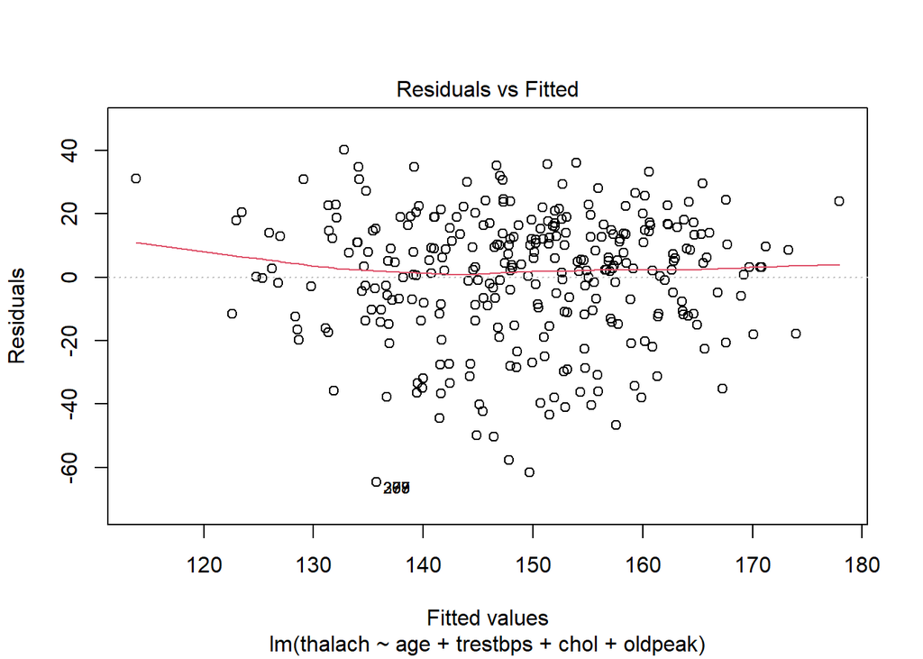

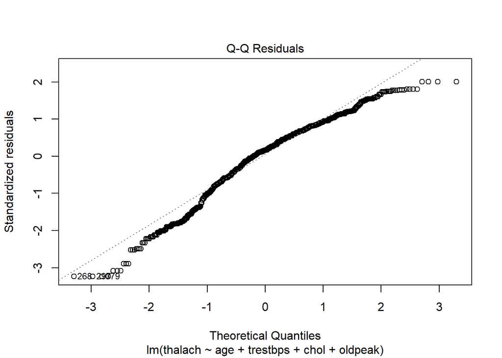

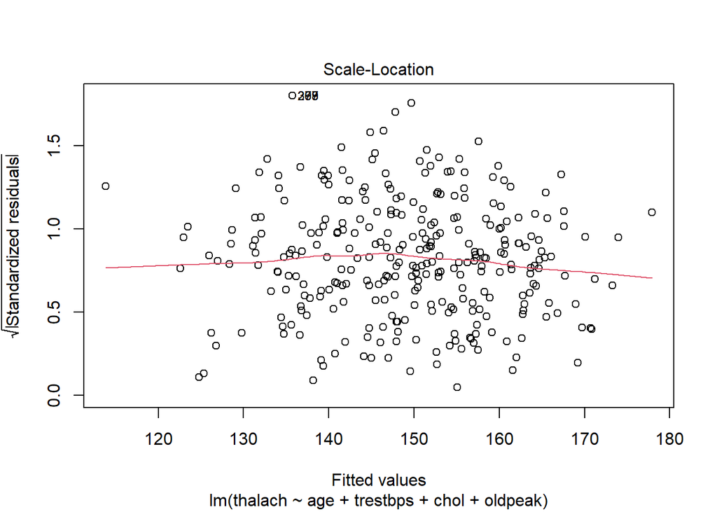

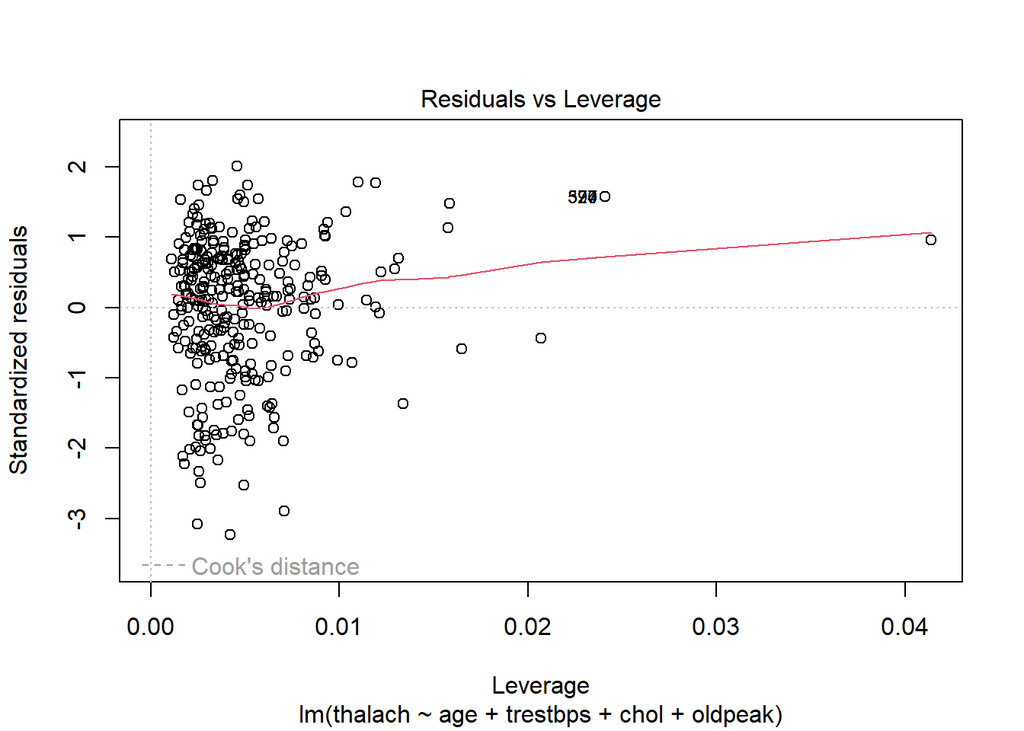

```r
plot(fit)
```

In the resudual vs fitted plot , it is almost same. The dotted line is nearby red line. So the data is normally distributed.

The Q-Q plot indicates that the residuals of the model are not perfectly normal, particularly at the tails, the central portion of the data follows the expected pattern closely. This might be acceptable in many practical situations,

This is the homoscedasticity , the values are equally scattered.

```r
coefficients(fit)
```

```
##  (Intercept)          age     trestbps         chol      oldpeak
## 180.72923414  -0.94418609   0.14312658   0.02916137  -5.81417065
```

```r
confint(fit,level=0.95)
```

```
##                     2.5 %      97.5 %
## (Intercept) 169.358462168 192.1000061
## age          -1.089609092  -0.7987631
## trestbps      0.069306756   0.2169464
## chol          0.004667538   0.0536552
## oldpeak      -6.894456984  -4.7338843
```

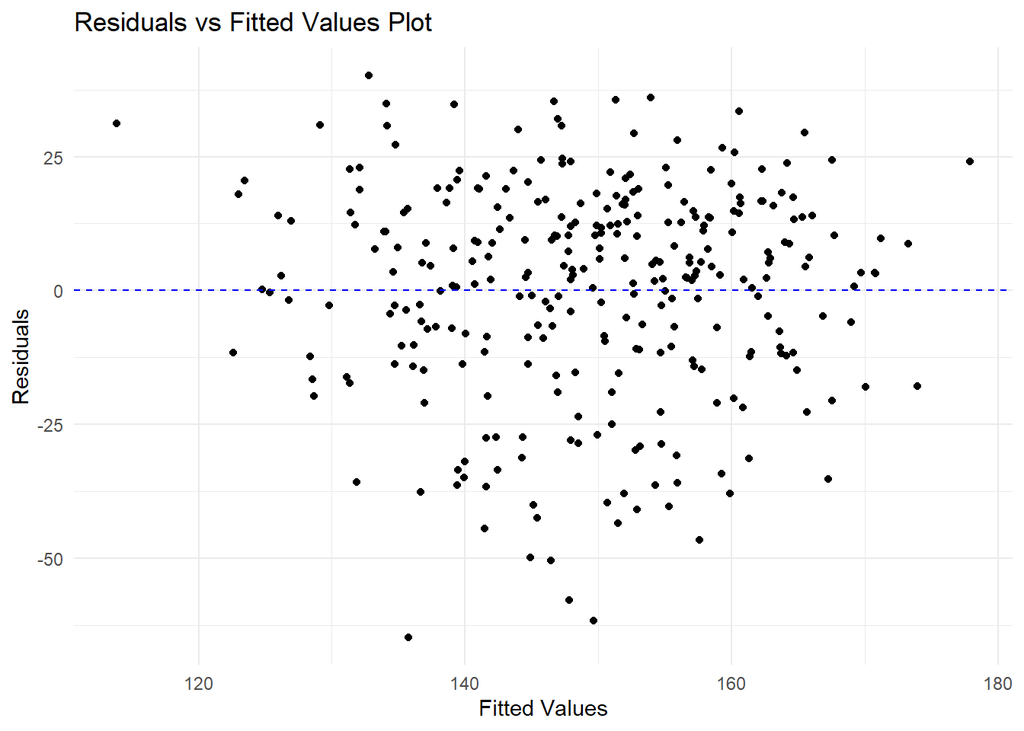

```r
# Create a dataframe with fitted values and residuals
residuals_df <- data.frame(
  fitted_values = fitted(fit),
  residuals = residuals(fit)
)

# Load the ggplot2 library if not already loaded
library(ggplot2)

# Plot residuals against fitted values to check for homoscedasticity
plot_resid_fitted <- ggplot(residuals_df, aes(x = fitted_values, y = residuals)) +
  geom_point() +
  geom_hline(yintercept = 0, linetype = "dashed", color = "blue") +
  labs(x = "Fitted Values", y = "Residuals",
       title = "Residuals vs Fitted Values Plot") +
  theme_minimal()

print(plot_resid_fitted)
```

In this plot:

The horizontal axis is labeled “Fitted Values,” which represent the values predicted by the regression model.

The vertical axis is labeled “Residuals,” which are the differences between the observed values and the fitted (predicted) values for each observation in the dataset.

The points on the plot are the individual observations. Each point represents one observation’s residual corresponding to its fitted value.

A horizontal dashed line at zero on the residuals axis represents the ideal case where the residuals would be if the model perfectly predicted the observed values.

#Prediction

```r
new_data <- data.frame(predict.lm(fit, data.frame( age= 70, trestbps=145,  chol=300 , oldpeak=3)))
new_data
```

```
##   predict.lm.fit..data.frame.age...70..trestbps...145..chol...300..
## 1                                                          126.6955
```

# Model Accuracy

```r
rsquared <- summary(fit)$r.squared
cat("R-squared:", rsquared, "\n")
```

```
## R-squared: 0.2434723
```

```r
adjusted_rsquared <- summary(fit)$adj.r.squared
cat("Adjusted R-squared:", adjusted_rsquared, "\n")
```

```
## Adjusted R-squared: 0.2405055
```

#Nonlinearity # component + residual plot

```r
library(car)
```

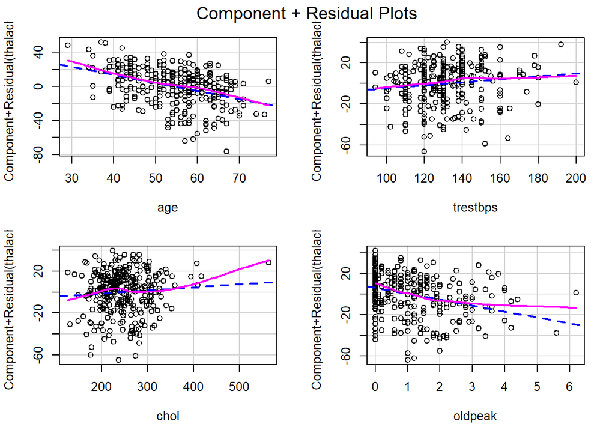

```r
crPlots(fit)
```

The bottom left plot shows the relationship for “chol” (possibly cholesterol levels) with the dependent variable. This plot reveals a slight positive trend, suggesting that higher cholesterol levels might be associated with an increase in the dependent variable.

The bottom right plot represents the variable “oldpeak” (which might relate to ST depression induced by exercise relative to rest) against the dependent variable. There is a noticeable negative trend, as the purple line slopes downwards.

# plot studentized residuals vs. fitted values

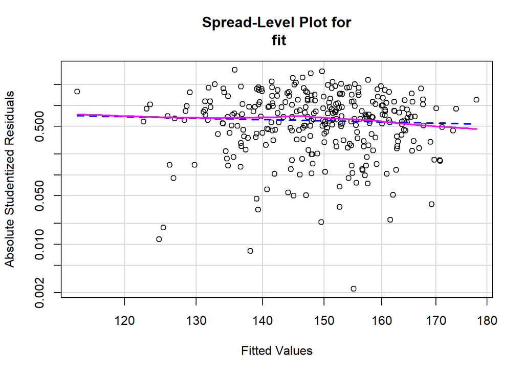

```
##
## Suggested power transformation:  1.608289
```

```r
library(car)
spreadLevelPlot(fit)
```

In the plot:

The x-axis represents the fitted values (the predicted values from the regression model). The y-axis shows the absolute standardized residuals (the absolute value of the residuals, which are the differences between the observed values and the fitted values, standardized by dividing by an estimate of the standard deviation of the residuals).

#LDA(Linear_Discrimination_Analysis)

```r
Ldata <- as.matrix(data2[, c(10:14)])
row.names(Ldata) <- row.names(data2)
Lraw <- cbind(Ldata, as.numeric(as.factor(data2$target)) - 1)
colnames(Lraw)[ncol(Lraw)] <- "diagnosis"
smp_size_raw <- floor(0.75 * nrow(Lraw))
train_ind_raw <- sample(nrow(Lraw), size = smp_size_raw)
train_raw.df <- as.data.frame(Lraw[train_ind_raw, ])
test_raw.df <- as.data.frame(Lraw[-train_ind_raw, ])
Lraw.lda <- lda(formula = diagnosis ~ ., data = train_raw.df)
Lraw.lda
```

```
## Call:
## lda(diagnosis ~ ., data = train_raw.df)
##
## Prior probabilities of groups:
##         0         1
## 0.4765625 0.5234375
##
## Group means:
##        age trestbps     chol  thalach   oldpeak
## 0 56.28142 134.6557 250.7131 138.0519 1.5838798
## 1 52.46766 129.3483 240.9055 158.0398 0.5597015
##
## Coefficients of linear discriminants:
##                    LD1
## age       0.0004021632
## trestbps -0.0068421073
## chol     -0.0029050167
## thalach   0.0304184498
## oldpeak  -0.5848674985
```

#Summary

```r
summary(Lraw.lda)
```

```
##         Length Class  Mode
## prior    2     -none- numeric
## counts   2     -none- numeric
## means   10     -none- numeric
## scaling  5     -none- numeric
## lev      2     -none- character
## svd      1     -none- numeric
## N        1     -none- numeric
## call     3     -none- call
## terms    3     terms  call
## xlevels  0     -none- list
```

```r
print(Lraw.lda)
```

```
## Call:
## lda(diagnosis ~ ., data = train_raw.df)
##
## Prior probabilities of groups:
##         0         1
## 0.4765625 0.5234375
##
## Group means:
##        age trestbps     chol  thalach   oldpeak
## 0 56.28142 134.6557 250.7131 138.0519 1.5838798
## 1 52.46766 129.3483 240.9055 158.0398 0.5597015
##
## Coefficients of linear discriminants:
##                    LD1
## age       0.0004021632
## trestbps -0.0068421073
## chol     -0.0029050167
## thalach   0.0304184498
## oldpeak  -0.5848674985
```

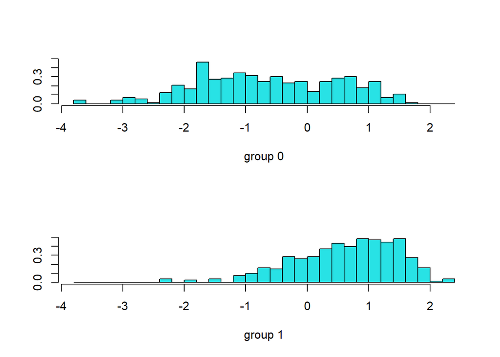

```r
plot(Lraw.lda)
```

These histograms represent the distributions of Linear Discriminant Analysis (LDA) scores for two different groups or classes in a dataset. LDA is a technique used in statistics and machine learning for pattern classification and dimensionality reduction. It projects the data onto a lower-dimensional space where the classes are most separable.

In the context of LDA:

Classes (groups) are typically predefined based on the labels in the dataset.

LDA tries to find a linear combination of features that best separates the different classes.

The resulting histograms show the distribution of the projected data along the LDA component axis for each class.

```r
# Make predictions on the test data
Lraw.lda.predict <- predict(Lraw.lda, newdata = test_raw.df)

# Extract predicted classes
Lraw.lda.predict$class
```

```
##   [1] 0 1 0 0 0 1 0 0 1 1 1 1 1 1 1 0 0 1 1 1 1 0 1 1 0 0 1 1 0 1 0 0 1 0 0 0 1
##  [38] 1 1 1 1 1 0 1 1 1 1 0 0 1 0 1 1 0 0 1 0 1 1 0 1 1 1 1 0 1 0 1 1 1 0 1 1 1
##  [75] 0 1 1 0 1 1 1 0 1 0 1 1 1 0 1 1 0 1 1 1 0 1 1 1 1 1 0 1 1 0 0 0 0 1 0 0 0
## [112] 0 0 1 1 0 1 0 1 1 1 0 0 1 1 1 0 1 1 0 1 1 1 0 0 1 0 1 1 1 0 0 1 0 0 1 1 0
## [149] 1 1 1 0 0 1 1 1 0 0 0 0 0 0 0 0 0 1 1 0 1 0 1 0 0 1 1 1 1 0 1 1 0 1 1 1 1
## [186] 1 1 1 1 1 1 1 0 1 0 0 1 1 0 0 0 0 0 1 0 1 0 0 1 1 0 1 1 0 0 1 1 0 0 1 1 1
## [223] 0 1 1 0 1 1 0 0 0 1 1 1 1 1 0 1 0 0 0 1 0 1 1 0 1 1 1 1 1 0 1 1 1 0 0
## Levels: 0 1
```

```r
Lraw.lda.predict$x
```

```
##              LD1
## 2    -0.93538596
## 4     1.00869443
## 6    -0.56600370
## 10   -2.29774854
## 14   -2.85932996
## 15    0.40205235
## 18   -1.88139407
## 21   -0.82179377
## 25    1.54022363
## 28    0.47884525
## 38    1.51755749
## 43    1.00626285
## 44    0.07560258
## 45    0.16220910
```

[output cut: 243 more lines]

#Accuracy

```r
# Get the predicted classes
predicted_classes <- predict(Lraw.lda, newdata = test_raw.df)$class

# Calculate accuracy
accuracy <- mean(predicted_classes == test_raw.df$diagnosis)
accuracy
```

```
## [1] 0.7315175
```

#ROC Plot

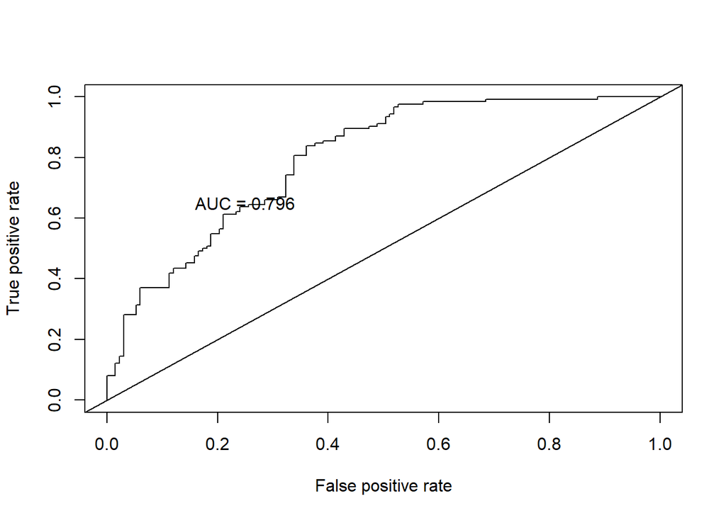

```r
# Get the posteriors as a dataframe
Lraw.lda.predict.posteriors <- as.data.frame(predict(Lraw.lda, newdata = test_raw.df)$posterior)

# Calculate the performance metrics
pred <- prediction(Lraw.lda.predict.posteriors[, 2], test_raw.df$diagnosis)
roc.perf <- performance(pred, measure = "tpr", x.measure = "fpr")
auc.train <- performance(pred, measure = "auc")@y.values

# Plot the ROC curve
plot(roc.perf)
abline(a = 0, b = 1)
text(x = 0.25, y = 0.65, paste("AUC = ", round(auc.train[[1]], 3), sep = ""))
```

In this ROC curve:

The x-axis represents the False Positive Rate (FPR): the proportion of negative instances that are incorrectly classified as positive. The y-axis represents the True Positive Rate (TPR): the proportion of positive instances that are correctly classified. The plot also includes a diagonal line, which represents the performance of a completely random classifier (AUC = 0.5). An ideal classifier would yield a point in the upper left corner of the ROC space, corresponding to a TPR of 1 (perfect sensitivity) and an FPR of 0 (perfect specificity).

#Logistic_Regression

```r
library(tidyverse)
library(readr)
library(ROCR)
library(PerformanceAnalytics)
library(e1071)
library(caret)
library(gbm)
library(corrplot)
library(ggcorrplot)
library(MASS)
library(rpart)
library(caTools)
library(naivebayes)
library(class)
library(ISLR)
library(glmnet)
library(Hmisc)
library(funModeling)
library(pROC)
library(randomForest)
library(klaR)
library(scales)
library(cluster)
library(factoextra)
library(DataExplorer)
library(ClustOfVar)
library(GGally)
library(dplyr)
library(visdat)
```

```r
file_path <- "D:/Multivariate Analysis/Final_Project/heart.csv"
data <- read.csv(file_path)
head(data)
```

```
##   age sex cp trestbps chol fbs restecg thalach exang oldpeak slope ca thal
## 1  52   1  0      125  212   0       1     168     0     1.0     2  2    3
## 2  53   1  0      140  203   1       0     155     1     3.1     0  0    3
## 3  70   1  0      145  174   0       1     125     1     2.6     0  0    3
## 4  61   1  0      148  203   0       1     161     0     0.0     2  1    3
## 5  62   0  0      138  294   1       1     106     0     1.9     1  3    2
## 6  58   0  0      100  248   0       0     122     0     1.0     1  0    2
##   target
## 1      0
## 2      0
## 3      0
## 4      0
## 5      0
## 6      1
```

#Transformation

```r
data2 <- data %>%
  mutate(sex = if_else(sex == 1, "MALE", "FEMALE"),
         fbs = if_else(fbs == 1, ">120", "<=120"),
         exang = if_else(exang == 1, "YES" ,"NO"),
         cp = if_else(cp == 1, "ATYPICAL ANGINA",
                      if_else(cp == 2, "NON-ANGINAL PAIN", "ASYMPTOMATIC")),
         restecg = if_else(restecg == 0, "NORMAL",
                           if_else(restecg == 1, "ABNORMALITY", "PROBABLE OR DEFINITE")),
         slope = as.factor(slope),
         ca = as.factor(ca),
         thal = as.factor(thal),
         target = if_else(target == 1, "UNHEALTHY", "HEALTHY")
         ) %>%
  mutate_if(is.character, as.factor) %>%
  dplyr::select(target, sex, fbs, exang, cp, restecg, slope, ca, thal, everything())
```

```r
str(data2)
```

```
## 'data.frame':    1025 obs. of  14 variables:
##  $ target  : Factor w/ 2 levels "HEALTHY","UNHEALTHY": 1 1 1 1 1 2 1 1 1 1 ...
##  $ sex     : Factor w/ 2 levels "FEMALE","MALE": 2 2 2 2 1 1 2 2 2 2 ...
##  $ fbs     : Factor w/ 2 levels "<=120",">120": 1 2 1 1 2 1 1 1 1 1 ...
##  $ exang   : Factor w/ 2 levels "NO","YES": 1 2 2 1 1 1 1 2 1 2 ...
##  $ cp      : Factor w/ 3 levels "ASYMPTOMATIC",..: 1 1 1 1 1 1 1 1 1 1 ...
##  $ restecg : Factor w/ 3 levels "ABNORMALITY",..: 1 2 1 1 1 2 3 2 2 2 ...
##  $ slope   : Factor w/ 3 levels "0","1","2": 3 1 1 3 2 2 1 2 3 2 ...
##  $ ca      : Factor w/ 5 levels "0","1","2","3",..: 3 1 1 2 4 1 4 2 1 3 ...
##  $ thal    : Factor w/ 4 levels "0","1","2","3": 4 4 4 4 3 3 2 4 4 3 ...
##  $ age     : int  52 53 70 61 62 58 58 55 46 54 ...
##  $ trestbps: int  125 140 145 148 138 100 114 160 120 122 ...
##  $ chol    : int  212 203 174 203 294 248 318 289 249 286 ...
##  $ thalach : int  168 155 125 161 106 122 140 145 144 116 ...
##  $ oldpeak : num  1 3.1 2.6 0 1.9 1 4.4 0.8 0.8 3.2 ...
```

# Now we see how many rows of data have NA values

```r
nrow(data2[is.na(data2$ca) | is.na(data2$thal), ])
```

```
## [1] 0
```

There is no rows of data having NAs in them.

It is now necessary to ensure that samples of both healthy and diseased individuals are taken from each gender (male and female). We should presumably eliminate every female from the model if heart disease is limited to male samples.

```r
xtabs(~ target + sex, data=data2)
```

```
##            sex
## target      FEMALE MALE
##   HEALTHY       86  413
##   UNHEALTHY    226  300
```

Healthy and Unhealthy patients are both represented by a lot of female and male samples.

For all 3 levels of chest pain reported by patients

```r
xtabs(~ target + cp, data=data2)
```

```
##            cp
## target      ASYMPTOMATIC ATYPICAL ANGINA NON-ANGINAL PAIN
##   HEALTHY            401              33               65
##   UNHEALTHY          173             134              219
```

```r
xtabs(~ target + fbs, data=data2)
```

```
##            fbs
## target      <=120 >120
##   HEALTHY     417   82
##   UNHEALTHY   455   71
```

```r
xtabs(~ target + restecg, data=data2)
```

```
##            restecg
## target      ABNORMALITY NORMAL PROBABLE OR DEFINITE
##   HEALTHY           204    283                   12
##   UNHEALTHY         309    214                    3
```

```r
xtabs(~ target + exang, data=data2)
```

```
##            exang
## target       NO YES
##   HEALTHY   225 274
##   UNHEALTHY 455  71
```

```r
xtabs(~ target + slope, data=data2)
```

```
##            slope
## target        0   1   2
##   HEALTHY    46 324 129
##   UNHEALTHY  28 158 340
```

```r
xtabs(~ target + ca, data=data2)
```

```
##            ca
## target        0   1   2   3   4
##   HEALTHY   163 160 113  60   3
##   UNHEALTHY 415  66  21   9  15
```

```r
xtabs(~ target + thal, data=data2)
```

```
##            thal
## target        0   1   2   3
##   HEALTHY     4  43 132 320
##   UNHEALTHY   3  21 412  90
```

#Applying Rgression model A simple model in which we will try to predict heart disease only using the gender of eah patient.

```r
logistic <- glm(target ~ sex, data = data2, family = "binomial")
summary(logistic)
```

```
##
## Call:
## glm(formula = target ~ sex, family = "binomial", data = data2)
##
## Coefficients:
##             Estimate Std. Error z value Pr(>|z|)
## (Intercept)   0.9662     0.1267   7.626 2.42e-14 ***
## sexMALE      -1.2859     0.1477  -8.707  < 2e-16 ***
## ---
## Signif. codes:  0 '***' 0.001 '**' 0.01 '*' 0.05 '.' 0.1 ' ' 1
##
## (Dispersion parameter for binomial family taken to be 1)
##
##     Null deviance: 1420.2  on 1024  degrees of freedom
## Residual deviance: 1337.8  on 1023  degrees of freedom
## AIC: 1341.8
##
## Number of Fisher Scoring iterations: 4
```

Here the glm() function that performs Generalized Linear Models. we used formula syntax(hd~sex) to predict heart disease(target). Then we specify the data(data=data2) that we are using for this model. In last, we specify that we want the binomial family of generalized linear models. This makes the glm() function do logistic regression, as apposed to some other type of generalized linear model. we are storing the output from glm() in a variable called “logistic”. Then use the summary function to get details about the logistic regression.

The output std.error and z value shows how the Walds test was computed for both coefficients.

The p-values(Pr(>|z|)) are well below 0.05 and thus, the log(odds) and the log(odd ratio) are both statstically significant.

When we do “normal linear regression , we estimate both the mean and variance from the data”. In contrast, with logistic regression, we estimate the mean of the data, and the variance is derived from the mean. Since we are not estimating the variance from the data(instead of just deriving it from the mean), it is possible that the variance is underestimated. If so, you can adjust the dispersion parameter in the summary command.

The null deviance and residuals deviance can be used to compare models , compute R^2 and an overall P-value.

Lastly, we have the number of Fisher Scoring iterations, which just tell us how quickly the glm() function converged on the maximum likelihood estimates for the coefficients

```r
median(data2$age)
```

```
## [1] 56
```

```r
logistic <- glm(target~ sex, data=data2, family= "binomial")
```

we have done a simple logistic regression using just one of the variables (sex) to predict heart disease, we can create a fancy model that uses all of the variables to predict heart disease.

```r
logistic <- glm(target~ ., data=data2, family= "binomial")
summary(logistic)
```

```
##
## Call:
## glm(formula = target ~ ., family = "binomial", data = data2)
##
## Coefficients:
##                              Estimate Std. Error z value Pr(>|z|)
## (Intercept)                 -1.217015   1.731518  -0.703  0.48214
## sexMALE                     -1.562843   0.286515  -5.455 4.91e-08 ***
## fbs>120                      0.557247   0.303949   1.833  0.06675 .
## exangYES                    -0.988474   0.236523  -4.179 2.93e-05 ***
## cpATYPICAL ANGINA            0.405498   0.297009   1.365  0.17217
## cpNON-ANGINAL PAIN           1.366619   0.255297   5.353 8.65e-08 ***
## restecgNORMAL               -0.320353   0.209060  -1.532  0.12544
## restecgPROBABLE OR DEFINITE -1.367008   1.362781  -1.003  0.31581
## slope1                      -0.377617   0.429038  -0.880  0.37878
## slope2                       0.743280   0.473771   1.569  0.11668
## ca1                         -2.216707   0.271674  -8.159 3.37e-16 ***
## ca2                         -3.246612   0.406198  -7.993 1.32e-15 ***
## ca3                         -2.546774   0.508091  -5.012 5.37e-07 ***
## ca4                          1.184139   0.873710   1.355  0.17532
## thal1                        2.418942   1.138722   2.124  0.03365 *
## thal2                        2.470571   1.091652   2.263  0.02363 *
## thal3                        1.010352   1.095374   0.922  0.35633
## age                          0.031507   0.013491   2.335  0.01953 *
## trestbps                    -0.017261   0.006220  -2.775  0.00552 **
## chol                        -0.006188   0.002214  -2.795  0.00519 **
## thalach                      0.024631   0.006031   4.084 4.43e-05 ***
## oldpeak                     -0.289628   0.128316  -2.257  0.02400 *
## ---
## Signif. codes:  0 '***' 0.001 '**' 0.01 '*' 0.05 '.' 0.1 ' ' 1
##
## (Dispersion parameter for binomial family taken to be 1)
##
##     Null deviance: 1420.24  on 1024  degrees of freedom
## Residual deviance:  648.79  on 1003  degrees of freedom
## AIC: 692.79
##
## Number of Fisher Scoring iterations: 6
```

This formula syntax, target~., means that we want to model heart disease(target) using all of the remaining variables in our data.frame called “data2”.

The predictors with p-values less than 0.05 are: sexMALE, exangYES, cpNON-ANGINAL PAIN, ca1, ca2, ca3, thal1, thal2, age, trestbps, chol, thalach, oldpeak.

On the bottom of the output, we see that the Residual Deviance and the AIC are much smaller for this fancy model than they were for the simple model, when we only used gender to predict heart disease.

If we want to calculate the McFadden’s Pseudo R^2 , we can pull the log -likelihood of the null model out of the logistic variable by getting the value for the null deviance and dividing by -2 and we can pull the log-likelihood for the fancy model out of the logistic variable by getting the value for the residual deviance and dividing by -2.

```r
ll.null <- logistic$null.deviance/-2
ll.proposed <- logistic$deviance/-2

## McFadden's Pseudo R^2 = [ LL(Null) - LL(Proposed) ] / LL(Null)
(ll.null - ll.proposed) / ll.null
```

```
## [1] 0.5431804
```

Then we just do the math and ended up with a Pseudo R^2 = 0.54. This can ne interpreted as the overall effect size. And we can use the same log_likelihoods to calculate a P_valuefor that R^2 using a Chi-square distribution.

```r
1 - pchisq(2*(ll.proposed - ll.null), df=(length(logistic$coefficients)-1))
```

```
## [1] 0
```

In this case, the tiny P-value indicates that the R^2 value is not a result of random chance.

Lastly, we can draw a graph that shows the predicted probabilities that each patient has heart disease along with their actual heart disease status.

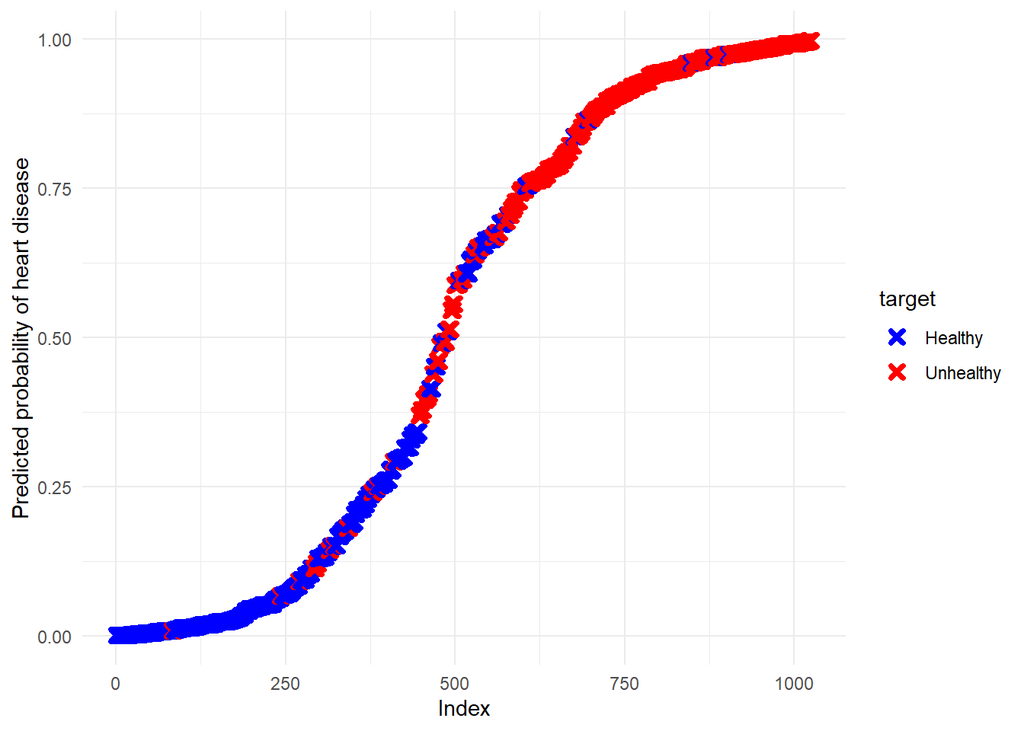

```r
## Load necessary libraries
library(ggplot2)
library(cowplot)
## Create a data frame with predicted probabilities and actual heart disease status
predicted.data <- data.frame(
  probability.of.target = logistic$fitted.values,
  target = ifelse(data$target == 0, "Healthy", "Unhealthy")
)

## Order the predicted data by probability of target, and add a rank column (sort the data.frame from low probabilities to high probabilities)
predicted.data <- predicted.data[order(predicted.data$probability.of.target, decreasing = FALSE), ]
# Then we add a new column to the data.frame that is rank of each sample , from low probabability to high probability.
predicted.data$rank <- 1:nrow(predicted.data)

## Plot the predicted probabilities for each sample, color by actual heart disease status
ggplot(data = predicted.data, aes(x = rank, y = probability.of.target)) +
  geom_point(aes(color = target), alpha = 1, shape = 4, stroke = 2) +
  scale_color_manual(values = c("Healthy" = "blue", "Unhealthy" = "red")) +  ## Customize colors
  xlab("Index") +
  ylab("Predicted probability of heart disease") +
  theme_minimal()
```

```r
## Save the plot as a PDF
ggsave("heart_disease_probabilities.pdf")
```

Most of the patients with heart disease (the red ones), are predicted to have a high probability of having heart disease and most of the patients without heart disease (the blue ones) are predicted to have a low probability of having a heart disease. Thus logistic regression has done a pretty good job.